# Reproducible Research: Peer Assessment 1

Taehee

June 10, 2016

## Course Project 1

This assigment is course project 1 for Reproducible research.

This assignment makes use of data from a personal activity monitoring device.

## Loading and preprocessing the data

```r
data<-read.csv("activity.csv")
#head(data)
#steps<-data$steps
#mean(is.na(steps))
data$date <- as.Date(as.character(data$date),"%Y-%m-%d")
```

## Histogram of the total number of steps taken each day

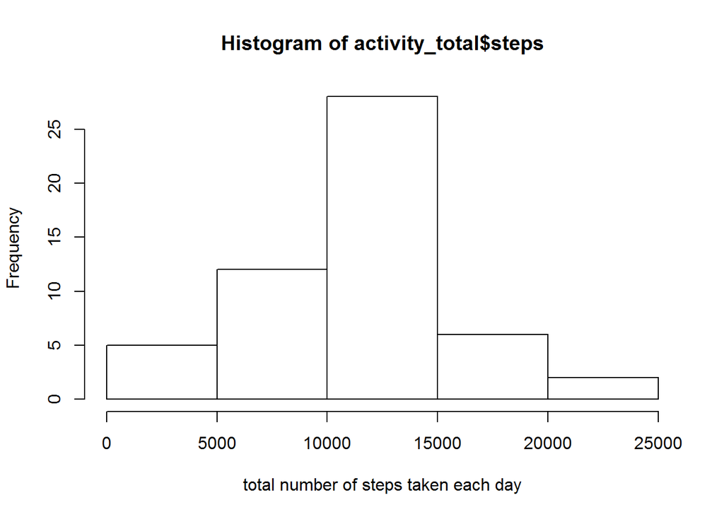

```r
#plot(data$date,data$steps,pch=20)
#Totstep <- with(data, tapply(steps, date, sum, na.rm = TRUE))
activity_total<-aggregate(steps ~ date,data,sum, na.rm = TRUE)
hist(activity_total$steps,xlab="total number of steps taken each day")
```

## Mean and median number of steps taken each day

```r
activity_mean<-aggregate(steps ~ date,data,mean, na.rm = TRUE)
print(activity_mean)
```

```
##          date      steps
## 1  2012-10-02  0.4375000
## 2  2012-10-03 39.4166667
## 3  2012-10-04 42.0694444
## 4  2012-10-05 46.1597222
## 5  2012-10-06 53.5416667
## 6  2012-10-07 38.2465278
## 7  2012-10-09 44.4826389
## 8  2012-10-10 34.3750000
## 9  2012-10-11 35.7777778
## 10 2012-10-12 60.3541667
## 11 2012-10-13 43.1458333
## 12 2012-10-14 52.4236111
## 13 2012-10-15 35.2048611
## 14 2012-10-16 52.3750000
```

[output cut: 39 more lines]

```r
activity_median<-aggregate(steps ~ date,data,median, na.rm = TRUE)
print(activity_median)
```

```
##          date steps
## 1  2012-10-02     0
## 2  2012-10-03     0
## 3  2012-10-04     0
## 4  2012-10-05     0
## 5  2012-10-06     0
## 6  2012-10-07     0
## 7  2012-10-09     0
## 8  2012-10-10     0
## 9  2012-10-11     0
## 10 2012-10-12     0
## 11 2012-10-13     0
## 12 2012-10-14     0
## 13 2012-10-15     0
## 14 2012-10-16     0
```

[output cut: 39 more lines]

## Time series plot of the average number of steps taken

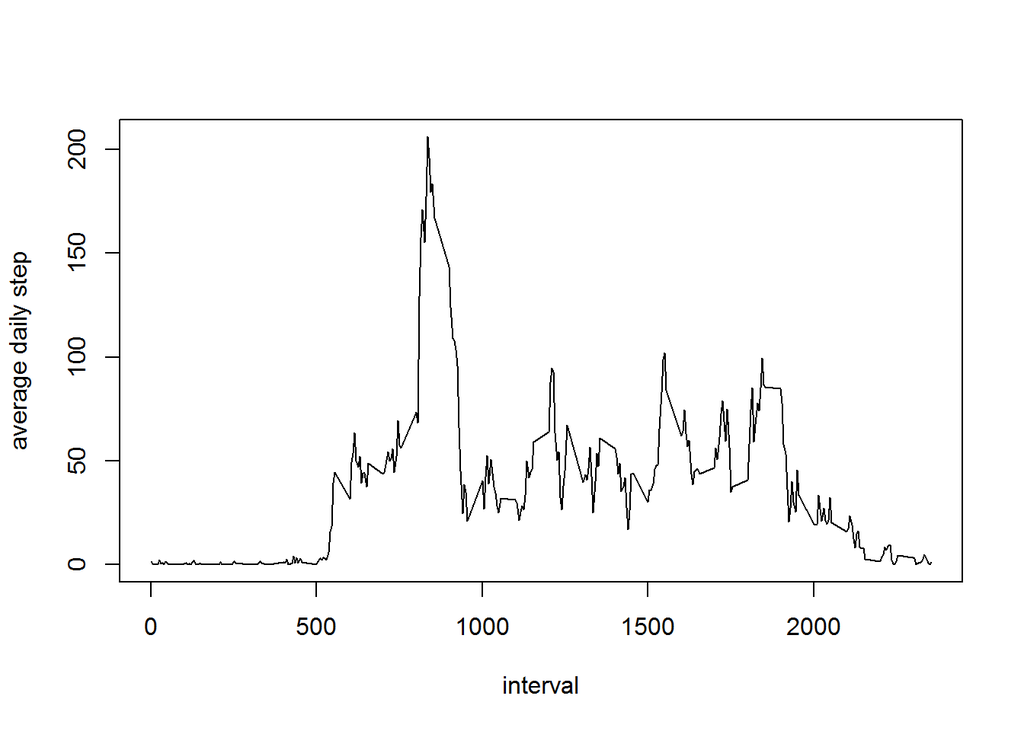

```r
activity_interval<-aggregate(steps ~ interval,data,mean,na.rm=TRUE)
with(activity_interval,plot(interval,steps,type="l",ylab="average daily step"))
```

5-minute interval, on average across all the days in the dataset, contains the maximum number of steps

```r
print(activity_interval[which.max(activity_interval$steps),1])
```

```
## [1] 835
```

## Imputing missing values

the total number of missing values in the dataset (i.e. the total number of rows with NAs)

```r
print(sum(is.na(data)))
```

```
## [1] 2304
```

create new data set

```r
data1<-data
```

filling in all of the missing values with the mean for that 5-minute interval

```r
for (i in 1:dim(data1)[1]){
  if (is.na(data1$steps[i])) {
    data1$steps[i]=activity_interval$steps[which(activity_interval$interval==data1$interval[i])]}
}
```

[figure not shown]

```r
activity_total1<-aggregate(steps ~ date,data,sum, na.rm = TRUE)
hist(activity_total1$steps,xlab="total number of steps taken each day after imputing missing values")
```

mean and median total number of steps taken per day

```r
activity_mean1<-aggregate(steps ~ date,data1,mean, na.rm = TRUE)
print(activity_mean1)
```

```
##          date      steps
## 1  2012-10-01 37.3825996
## 2  2012-10-02  0.4375000
## 3  2012-10-03 39.4166667
## 4  2012-10-04 42.0694444
## 5  2012-10-05 46.1597222
## 6  2012-10-06 53.5416667
## 7  2012-10-07 38.2465278
## 8  2012-10-08 37.3825996
## 9  2012-10-09 44.4826389
## 10 2012-10-10 34.3750000
## 11 2012-10-11 35.7777778
## 12 2012-10-12 60.3541667
## 13 2012-10-13 43.1458333
## 14 2012-10-14 52.4236111
```

[output cut: 47 more lines]

```r
activity_median1<-aggregate(steps ~ date,data1,median, na.rm = TRUE)
print(activity_median1)
```

```
##          date    steps
## 1  2012-10-01 34.11321
## 2  2012-10-02  0.00000
## 3  2012-10-03  0.00000
## 4  2012-10-04  0.00000
## 5  2012-10-05  0.00000
## 6  2012-10-06  0.00000
## 7  2012-10-07  0.00000
## 8  2012-10-08 34.11321
## 9  2012-10-09  0.00000
## 10 2012-10-10  0.00000
## 11 2012-10-11  0.00000
## 12 2012-10-12  0.00000
## 13 2012-10-13  0.00000
## 14 2012-10-14  0.00000
```

[output cut: 47 more lines]

## Are there differences in activity patterns between weekdays and weekends?

Create a new factor variable in the dataset with two levels - “weekday” and “weekend”

```r
data1$weekday<-weekdays(data1$date)
data1$weekend[data1$weekday %in% c("Saturday","Sunday")]<-"weekend"
data1$weekend[data1$weekday %in% c("Monday","Tuesday","Wednesday","Thursday","Friday")]<-"weekday"
data1$weekend<-factor(data1$weekend)
```

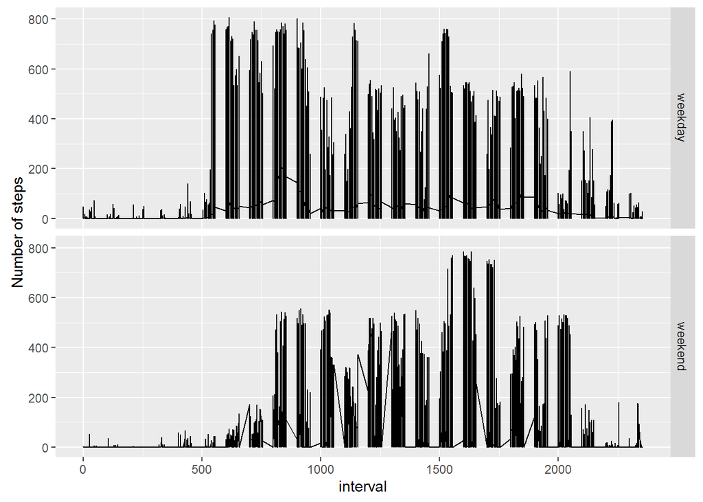

```r
library(ggplot2)
g<-ggplot(data1,aes(interval,steps))
g+geom_line()+facet_grid(weekend~.)+ylab("Number of steps")
```